# Dropout Prediction: A Systematic Literature Review

This was tested with bib2df version 1.1.1, installation instructions available [here](https://docs.ropensci.org/bib2df/), and one example [here](https://docs.ropensci.org/bib2df/articles/bib2df.html). Github project is available [here](https://github.com/ropensci/bib2df)

Is better to confirm that the files are in UTF-8 encoding. The bibtex files must be checked. There should be spaces between “=”:

```
@Article{Binmore2008,
  Title = {Do Conventions Need to Be Common Knowledge?},
  Author = {Binmore, Ken},
  Journal = {Topoi},
  Year = {2008},
  Number = {1},
  Pages = {17--27},
  Volume = {27}
}
```

This code correct that:

```
tx<-readLines(file)
tx2<-gsub(pattern = "=\\{",replacement = " = {",x = tx)
writeLines(text = tx2,con = 'corrected_scopus.bib')
```

The metagear package

# Import Libraries

```r
# Setup library
library(bib2df)
library(bibtex)
library(tibble)
library(dplyr)
library(readxl)
library(kableExtra) #Exportar tabelas para latex
library(ggplot2)


# get rmarkdown directory
caminho<-getwd()
# set working directory
setwd(caminho)
```

#Select only select articles

```r
data_asreview <- read_excel("asreview/asreview_result_dropout-prediction-a-systematic-literature-review-v3_FINAL.xlsx")
str(data_asreview)
```

```
tibble [402 x 13] (S3: tbl_df/tbl/data.frame)
 $ record_id       : num [1:402] 2 7 33 34 49 53 58 61 81 89 ...
 $ Unnamed: 0      : num [1:402] 3 9 35 36 51 55 60 63 83 92 ...
 $ category        : chr [1:402] "INPROCEEDINGS" "INPROCEEDINGS" "ARTICLE" "ARTICLE" ...
 $ year            : num [1:402] 2015 2017 2014 2019 2008 ...
 $ title           : chr [1:402] "A Case Study for the Churn Prediction in Turksat Internet Service Subscription" "Churn prediction model for effective gym customer retention" "Churn prediction using comprehensible support vector machine: An analytical CRM application" "A big data analytics model fo…
 $ abstract        : chr [1:402] "Churn prediction is a customer relationship process that predicts for customers who are at the brink of transfe"| __truncated__ "In the fitness industry, rolling gym membership contracts allow customers to terminate a contract with little a"| __truncated__ "Support …
 $ doi             : chr [1:402] "10.1145/2808797.2808821" "10.1109/BESC.2017.8256385" "https://doi.org/10.1016/j.asoc.2014.01.031" "https://doi.org/10.1016/j.ijinfomgt.2018.10.005" ...
 $ journal         : chr [1:402] NA NA "Applied Soft Computing" "International Journal of Information Management" ...
 $ bibtexkey       : chr [1:402] "10.1145/2808797.2808821" "8256385" "FARQUAD201431" "SHIRAZI2019238" ...
 $ author          : chr [1:402] "G\\\"ok, Mehmet, \\\"Ozyer, Tansel, Jida, Jamal" "J, Semrl, A, Matei" "M.A.H. Farquad, Vadlamani Ravi, S. Bapi Raju" "Farid Shirazi, Mahbobeh Mohammadi" ...
 $ source          : chr [1:402] "ACM" "IEEE" "SCIENCE" "SCIENCE" ...
 $ final_included  : num [1:402] 1 1 1 1 1 1 1 1 1 1 ...
 $ asreview_ranking: num [1:402] 1 2 3 4 5 6 7 8 9 10 ...
```

```r
data_asreview <- data_asreview[data_asreview$final_included==1,]

str(data_asreview)
```

```
tibble [91 x 13] (S3: tbl_df/tbl/data.frame)
 $ record_id       : num [1:91] 2 7 33 34 49 53 58 61 81 89 ...
 $ Unnamed: 0      : num [1:91] 3 9 35 36 51 55 60 63 83 92 ...
 $ category        : chr [1:91] "INPROCEEDINGS" "INPROCEEDINGS" "ARTICLE" "ARTICLE" ...
 $ year            : num [1:91] 2015 2017 2014 2019 2008 ...
 $ title           : chr [1:91] "A Case Study for the Churn Prediction in Turksat Internet Service Subscription" "Churn prediction model for effective gym customer retention" "Churn prediction using comprehensible support vector machine: An analytical CRM application" "A big data analytics model for…
 $ abstract        : chr [1:91] "Churn prediction is a customer relationship process that predicts for customers who are at the brink of transfe"| __truncated__ "In the fitness industry, rolling gym membership contracts allow customers to terminate a contract with little a"| __truncated__ "Support v…
 $ doi             : chr [1:91] "10.1145/2808797.2808821" "10.1109/BESC.2017.8256385" "https://doi.org/10.1016/j.asoc.2014.01.031" "https://doi.org/10.1016/j.ijinfomgt.2018.10.005" ...
 $ journal         : chr [1:91] NA NA "Applied Soft Computing" "International Journal of Information Management" ...
 $ bibtexkey       : chr [1:91] "10.1145/2808797.2808821" "8256385" "FARQUAD201431" "SHIRAZI2019238" ...
 $ author          : chr [1:91] "G\\\"ok, Mehmet, \\\"Ozyer, Tansel, Jida, Jamal" "J, Semrl, A, Matei" "M.A.H. Farquad, Vadlamani Ravi, S. Bapi Raju" "Farid Shirazi, Mahbobeh Mohammadi" ...
 $ source          : chr [1:91] "ACM" "IEEE" "SCIENCE" "SCIENCE" ...
 $ final_included  : num [1:91] 1 1 1 1 1 1 1 1 1 1 ...
 $ asreview_ranking: num [1:91] 1 2 3 4 5 6 7 8 9 10 ...
```

# Copy DOIs to clipboard to import to Zotero

```r
text<-as.character(data_asreview$doi)
text
```

```
 [1] "10.1145/2808797.2808821"                          "10.1109/BESC.2017.8256385"                        "https://doi.org/10.1016/j.asoc.2014.01.031"
 [4] "https://doi.org/10.1016/j.ijinfomgt.2018.10.005"  "https://doi.org/10.1016/S1874-8651(09)60003-X"    "https://doi.org/10.1016/j.eswa.2008.07.072"
 [7] "https://doi.org/10.1016/j.intmar.2010.04.002"     "https://doi.org/10.1016/j.dss.2016.11.007"        "https://doi.org/10.1016/j.eswa.2011.04.007"
[10] "https://doi.org/10.1016/j.asoc.2014.08.041"       "https://doi.org/10.1016/j.ejor.2019.03.037"       "https://doi.org/10.1016/j.neucom.2016.12.009"
[13] "https://doi.org/10.1016/j.ins.2019.12.075"        "https://doi.org/10.1016/j.jretconser.2019.101918" "https://doi.org/10.1016/j.eswa.2005.09.080"
[16] "https://doi.org/10.1016/j.dss.2011.01.002"        "10.1016/j.eswa.2020.113779"                       "10.1109/ICIEA49774.2020.9102099"
[19] "10.1007/s10115-019-01394-7"                       "10.1080/01605682.2020.1776166"                    "10.1007/s10586-017-1172-1"
[22] "10.1109/ICECCE47252.2019.8940667"                 "10.1140/epjds/s13688-018-0165-5"                  "10.1109/ICSCEE.2018.8538420"
[25] "10.1109/ICATCCT.2017.8389139"                     "10.1016/j.ejor.2017.12.015"                       "10.1089/big.2018.0015"
[28] "10.1509/jmr.16.0163"                              "10.1057/s41274-016-0176-1"                        "10.1007/978-981-10-8228-3_6"
[31] "10.1109/DSAA.2017.42"                             "10.1007/s10115-016-0995-z"                        "10.1108/JSIT-10-2016-0061"
[34] "10.1109/DSAA.2016.84"                             "10.1109/CICN.2015.123"                            "10.1109/ICDIM.2016.7829775"
[37] "10.1007/s10115-013-0722-y"                        "10.1016/j.dss.2015.02.007"                        "10.1016/j.eswa.2014.06.018"
[40] "10.1111/deci.12057"                               "10.3233/IDA-130625"                               "10.1109/ISTMET.2014.6936498"
[43] "10.4028/www.scientific.net/AMR.989-994.1517"      "10.1016/j.procs.2014.05.286"                      "10.1016/j.asoc.2013.09.017"
```

[output cut: 16 more lines]

```r
# writeClipboard(text)

length(text)
```

```
[1] 91
```

# Final list 91 records

Os artigos foram importados e vamos comparar quantos tempos no zotero e quantos tivemos no Wasnt possible to retrieve - A Case of Churn Prediction in Telecommunications Industry Duplicates: - Improving customer churn prediction by data augmentation using pictorial stimulus-choice data - Preventing Churn in Telecommunications: The Forgotten Network - Churn Prediction Model for Effective Gym Customer Retention

```r
articles.remove=c('A Case of Churn Prediction in Telecommunications Industry',
                  'Improving customer churn prediction by data augmentation using pictorial stimulus-choice data',
                  'Churn Prediction Model for Effective Gym Customer Retention',
                  'Preventing churn in telecommunications: The forgotten network')

data_asreview %>%subset(subset = (title %in% articles.remove)) %>% arrange(title)
```

| record_id | Unnamed: 0 | category | year | title | abstract | doi | journal | bibtexkey | author | source | final_included | asreview_ranking |
| --- | --- | --- | --- | --- | --- | --- | --- | --- | --- | --- | --- | --- |
| 399 | 418 | ARTICLE | 2019 | A Case of Churn Prediction in Telecommunications Industry | Churn prediction is the practice of assigning a probability to the event of a customer ending his contract with a service provider. Traditional data mining approaches to churn prediction in telecommun… | 10.1007/978-3-319-10774-5_8 | Ipsi Bgd Transactions on Internet Research | brmez_case_2019 | Brmez, Simon, Znidarsic, Martin | WOS | 1 | 90 |
| 400 | 419 | BOOK | 2017 | Churn Prediction Model for Effective Gym Customer Retention | In the fitness industry, rolling gym membership contracts allow customers to terminate a contract with little advanced notice. Customer churn prediction is a well known area in Machine Learning resear… | 10.1109/BESC.2017.8256385 | NA | semrl_churn_2017 | Semrl, Jas, Matei, Alexandru | WOS | 1 | 91 |
| 284 | 300 | INPROCEEDINGS | 2012 | Improving customer churn prediction by data augmentation using pictorial stimulus-choice data | The purpose of this paper is to determine the added value of pictorial stimulus-choice data in customer churn prediction. Using Random Forests and 5 times 2 fold cross-validation, this study analyzes … | 10.1007/978-3-642-30864-2_21 | NA | Ballings2012217 | Ballings, M., Van Den Poel, D., Verhagen, E. | SCOPUS | 1 | 55 |
| 264 | 280 | INPROCEEDINGS | 2013 | Preventing churn in telecommunications: The forgotten network | This paper outlines an approach developed as a part of a company-wide churn management initiative of a major European telecom operator. We are focusing on explanatory churn model for the postpaid segm… | 10.1007/978-3-642-41398-8_31 | NA | Radosavljevik2013357 | Radosavljevik, D., Van Der Putten, P. | SCOPUS | 1 | 46 |

Remover o que não interessa

```r
articles.remove=c('399','400','284','264')

data_asreview<-data_asreview %>%subset(subset = !(record_id %in% articles.remove)) %>% arrange(title)
```

‘C:/nuvem/Dropbox/doutoramento/tese/SLRDropout/analysis/selected_articles/final_dataset/FinalDataset.bib’

```r
data_asreview %>% select(title,doi) %>% distinct(title,.keep_all = TRUE) %>% arrange(title)
```

| title | doi |
| --- | --- |
| A big data analytics model for customer churn prediction in the retiree segment | https://doi.org/10.1016/j.ijinfomgt.2018.10.005 |
| A Case Study for the Churn Prediction in Turksat Internet Service Subscription | 10.1145/2808797.2808821 |
| A churn prediction model for prepaid customers in telecom using fuzzy classifiers | 10.1007/s11235-017-0310-7 |
| A comparative analysis of data preparation algorithms for customer churn prediction: A case study in the telecommunication industry | https://doi.org/10.1016/j.dss.2016.11.007 |
| A fuzzy prediction model for calling communities | 10.1504/IJNVO.2011.037162 |
| A Graph-Based Churn Prediction Model for Mobile Telecom Networks | 10.1007/978-3-642-35527-1_31 |
| A novel evolutionary data mining algorithm with applications to churn prediction | 10.1109/TEVC.2003.819264 |
| An efficient system for customer churn prediction through particle swarm optimization based feature selection model with simulated annealing | 10.1007/s10586-017-1172-1 |
| An empirical evaluation of rotation-based ensemble classifiers for customer churn prediction | https://doi.org/10.1016/j.eswa.2011.04.007 |
| An innovative optimized model to anticipate clients about immigration in telecom industry | 10.1109/ICATCCT.2017.8389139 |

[output cut: 77 more lines]

```r
library(metagear)
```

### Prisma Flow diagram

phases <- c(“START_PHASE: 448 of studies identified through database searching”, “START_PHASE: # of additional studies identified through other sources”, “# of studies after duplicates removed”, “# of studies with title and abstract screened”, “EXCLUDE_PHASE: # of studies excluded”, “# of full-text articles assessed for eligibility”, “EXCLUDE_PHASE: # of full-text excluded, not fitting eligibility criteria”, “# of studies included in qualitative synthesis”, “EXCLUDE_PHASE: # studies excluded, incomplete data reported”, “final # of studies included in quantitative synthesis (meta-analysis)”)

[output not shown]

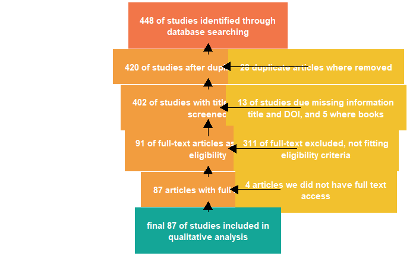

```r
phases <- c("START_PHASE: 448 of studies identified through database searching",
            "420 of studies after duplicates removed",
            "EXCLUDE_PHASE: 28 duplicate articles where removed",
            "402 of studies with title and abstract screened",
            "EXCLUDE_PHASE: 13 of studies due missing information title and DOI, and 5 where books",
            "91 of full-text articles assessed for eligibility",
            "EXCLUDE_PHASE: 311 of full-text excluded, not fitting eligibility criteria",
            "87 articles with full access",
            "EXCLUDE_PHASE: 4 articles we did not have full text access ",
            "final 87 of studies included in qualitative analysis")
#plot_PRISMA(phases,colWidth = 40, design = c(fontSize=10))
plot_PRISMA(phases,colWidth = 40, design = "cinnamonMint")
```

```r
str(data_asreview)
```

```
tibble [87 x 13] (S3: tbl_df/tbl/data.frame)
 $ record_id       : num [1:87] 34 2 336 61 295 342 322 168 81 202 ...
 $ Unnamed: 0      : num [1:87] 36 3 355 63 313 361 340 177 83 214 ...
 $ category        : chr [1:87] "ARTICLE" "INPROCEEDINGS" "ARTICLE" "ARTICLE" ...
 $ year            : num [1:87] 2019 2015 2017 2017 2011 ...
 $ title           : chr [1:87] "A big data analytics model for customer churn prediction in the retiree segment" "A Case Study for the Churn Prediction in Turksat Internet Service Subscription" "A churn prediction model for prepaid customers in telecom using fuzzy classifiers" "A comparative analys…
 $ abstract        : chr [1:87] "Undoubtedly, the change in consumersâ\200\231 choices and expectations, stemming from the emerging technology a"| __truncated__ "Churn prediction is a customer relationship process that predicts for customers who are at the brink of transfe"| __truncated__ "The incre…
 $ doi             : chr [1:87] "https://doi.org/10.1016/j.ijinfomgt.2018.10.005" "10.1145/2808797.2808821" "10.1007/s11235-017-0310-7" "https://doi.org/10.1016/j.dss.2016.11.007" ...
 $ journal         : chr [1:87] "International Journal of Information Management" NA "Telecommunication Systems" "Decision Support Systems" ...
 $ bibtexkey       : chr [1:87] "SHIRAZI2019238" "10.1145/2808797.2808821" "azeem_churn_2017" "COUSSEMENT201727" ...
 $ author          : chr [1:87] "Farid Shirazi, Mahbobeh Mohammadi" "G\\\"ok, Mehmet, \\\"Ozyer, Tansel, Jida, Jamal" "Azeem, Muhammad, Usman, Muhammad, Fong, A. C. M." "Kristof Coussement, Stefan Lessmann, Geert Verstraeten" ...
 $ source          : chr [1:87] "SCIENCE" "ACM" "SPRINGER" "SCIENCE" ...
 $ final_included  : num [1:87] 1 1 1 1 1 1 1 1 1 1 ...
 $ asreview_ranking: num [1:87] 4 1 80 8 59 82 72 21 9 25 ...
```

## Articles by Year

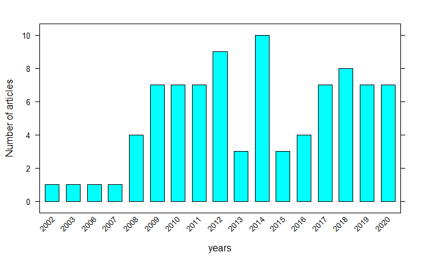

```r
library(lattice)
#Create contigency table for source column
tb<-table(data_asreview$year)
barchart(tb,horizontal = FALSE, scales = list(x = list(rot = 45)),ylab='Number of articles',xlab='years')
```

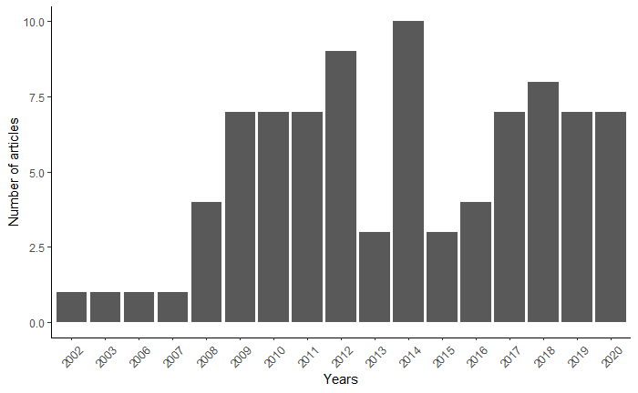

```r
d<-ggplot(data = data_asreview,mapping = aes(x = factor(data_asreview$year)))
  d+geom_bar()+labs(x='Years',y='Number of articles') + theme_classic()+
  theme(axis.text.x = element_text(angle = 45,vjust = 0.5))
```

```r
tb
```

```
2002 2003 2006 2007 2008 2009 2010 2011 2012 2013 2014 2015 2016 2017 2018 2019 2020
   1    1    1    1    4    7    7    7    9    3   10    3    4    7    8    7    7
```

## Articles by Journal

```r
# edit(data_asreview)
```

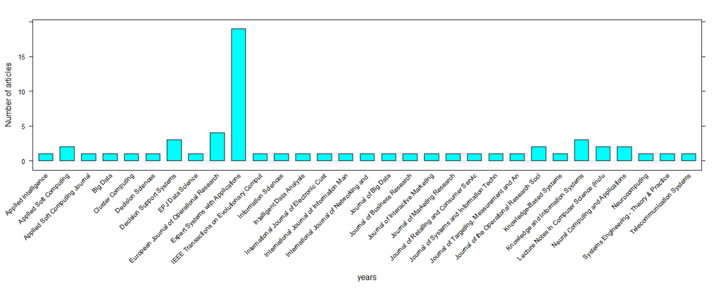

```r
library(lattice)
#Create contingency table for source column
tb<-table(substr(data_asreview$journal[!data_asreview$journal==''], start = 1, stop = 40))

barchart(tb,horizontal = FALSE, scales = list(x = list(rot = 45)),ylab='Number of articles',xlab='years')
```

A bit messy. Trying to regroup the magazines… replace conferences with conference…

```r
jornais<-data_asreview %>%
  select(journal) %>%
  group_by(journal) %>%
  summarize(count = n())


str(jornais)
```

```
tibble [32 x 2] (S3: tbl_df/tbl/data.frame)
 $ journal: chr [1:32] "Applied Intelligence" "Applied Soft Computing" "Applied Soft Computing Journal" "Big Data" ...
 $ count  : int [1:32] 1 2 1 1 1 1 3 1 4 19 ...
```

```r
# Select all NaNs
jornais[is.na.data.frame(jornais)]<-"Conference"

#view(jornais)
# Replace journals with one occurrence with others

#jornais[jornais$count==1,] <- "others"


#length(jornais[jornais$count==1,])


#jornais<-jornais %>%
#  select(journal) %>%
#  group_by(journal) %>%
#  summarize(count = n())
#
```

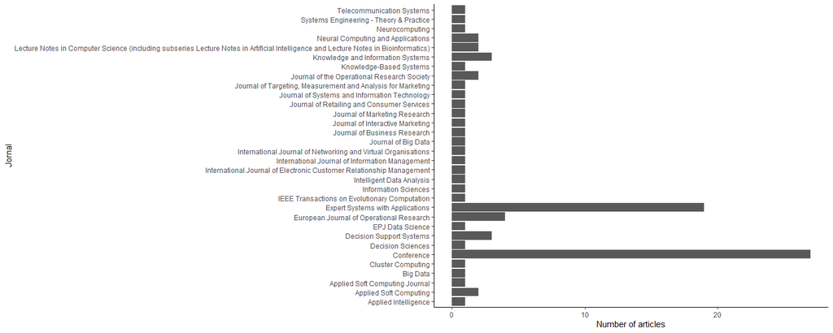

```r
d<-ggplot(data = jornais,mapping = aes(x = journal,y = count))
d+geom_col()+coord_flip()+labs(x='Jornal',y='Number of articles') + theme_classic()
```

Replace long text “Lecture Notes in Computer Science (…..)” with “Lecture Notes in Computer Science”

```r
#grepl return an vector logical values
jornais$journal[grepl("^Lecture Notes in",x = jornais$journal)]<-"Lecture Notes in Computer Science"
```

```r
table(substr(data_asreview$journal, start = 1, stop = 40))
```

```
                    Applied Intelligence                   Applied Soft Computing           Applied Soft Computing Journal                                 Big Data
                                       1                                        2                                        1                                        1
                       Cluster Computing                        Decision Sciences                 Decision Support Systems                         EPJ Data Science
                                       1                                        1                                        3                                        1
European Journal of Operational Research         Expert Systems with Applications IEEE Transactions on Evolutionary Comput                     Information Sciences
                                       4                                       19                                        1                                        1
               Intelligent Data Analysis International Journal of Electronic Cust International Journal of Information Man International Journal of Networking and
                                       1                                        1                                        1                                        1
                     Journal of Big Data             Journal of Business Research         Journal of Interactive Marketing            Journal of Marketing Research
                                       1                                        1                                        1                                        1
Journal of Retailing and Consumer Servic Journal of Systems and Information Techn Journal of Targeting, Measurement and An Journal of the Operational Research Soci
                                       1                                        1                                        1                                        2
                 Knowledge-Based Systems        Knowledge and Information Systems Lecture Notes in Computer Science (inclu        Neural Computing and Applications
                                       1                                        3                                        2                                        2
                          Neurocomputing  Systems Engineering - Theory & Practice                Telecommunication Systems
                                       1                                        1                                        1
```

```r
journals <- unique(data_asreview$journal)
sort(journals)
```

```
 [1] "Applied Intelligence"
 [2] "Applied Soft Computing"
 [3] "Applied Soft Computing Journal"
 [4] "Big Data"
 [5] "Cluster Computing"
 [6] "Decision Sciences"
 [7] "Decision Support Systems"
 [8] "EPJ Data Science"
 [9] "European Journal of Operational Research"
[10] "Expert Systems with Applications"
[11] "IEEE Transactions on Evolutionary Computation"
[12] "Information Sciences"
[13] "Intelligent Data Analysis"
[14] "International Journal of Electronic Customer Relationship Management"
[15] "International Journal of Information Management"
```

[output cut: 16 more lines]

```r
sort(journals[grepl(pattern = "Conference|conference",x = journals)])
```

```
character(0)
```

## Articles by Sources

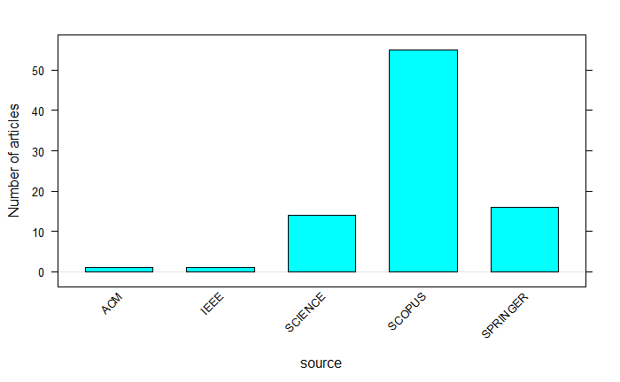

```r
#Create contigency table for source column
tb<-table(data_asreview$source)

barchart(tb,horizontal = FALSE, scales = list(x = list(rot = 45)),ylab='Number of articles',xlab='source')
```

```r
tb
```

```
     ACM     IEEE  SCIENCE   SCOPUS SPRINGER
       1        1       14       55       16
```

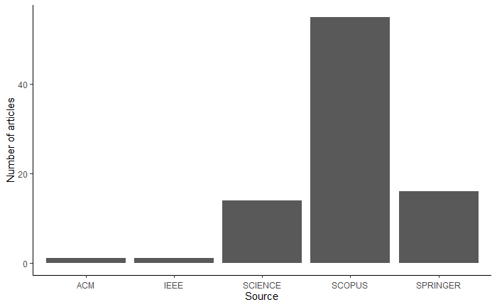

```r
d<-ggplot(data = data_asreview,mapping = aes(x = factor(data_asreview$source)))
  d+geom_bar()+labs(x='Source',y='Number of articles') + theme_classic()+
  theme(axis.text.x = element_text(angle = 0,vjust = 0.5))
```

## Articles by Category

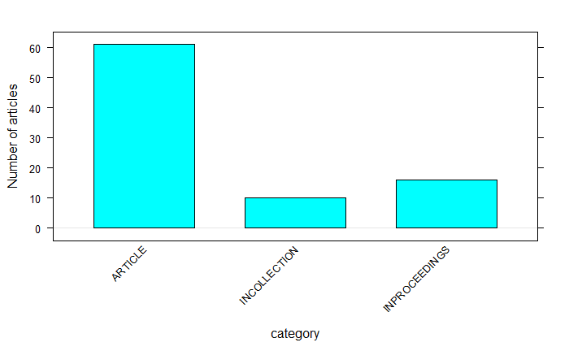

```r
library(lattice)
#Create contigency table for source column
tb<-table(data_asreview$category)

barchart(tb,horizontal = FALSE, scales = list(x = list(rot = 45)),ylab='Number of articles',xlab='category')
```

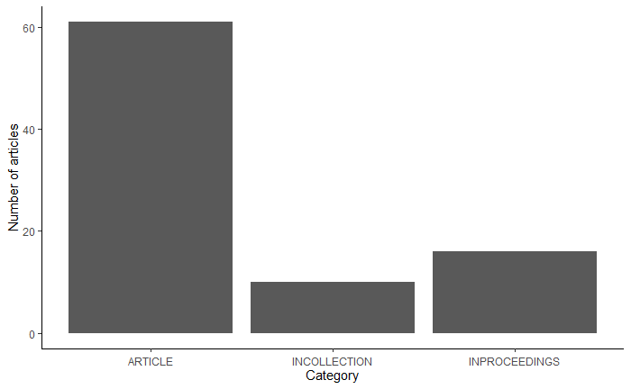

```r
d<-ggplot(data = data_asreview,mapping = aes(x = factor(data_asreview$category)))
  d+geom_bar()+labs(x='Category',y='Number of articles') + theme_classic()+
  theme(axis.text.x = element_text(angle = 0,vjust = 0.5))
```

## Final table of selected articles

data_articles %>% select(year,title) %>% kbl() %>% kable_minimal() %>% kable_styling()

```r
data_asreview %>%
  select(author,title) %>%
  kable("latex")
```

```r
data_asreview %>% select(author,title,source) %>% arrange(author)
```

| author | title | source |
| --- | --- | --- |
| A. Keramati, R. Jafari-Marandi, M. Aliannejadi, I. Ahmadian, M. Mozaffari, U. Abbasi | Improved churn prediction in telecommunication industry using data mining techniques | SCIENCE |
| Óskarsdóttir, M., Baesens, B., Vanthienen, J. | Profit-Based Model Selection for Customer Retention Using Individual Customer Lifetime Values | SCOPUS |
| Adnan Amin, Sajid Anwar, Awais Adnan, Muhammad Nawaz, Khalid Alawfi, Amir Hussain, Kaizhu Huang | Customer churn prediction in the telecommunication sector using a rough set approach | SCIENCE |
| Agrawal, S., Das, A., Gaikwad, A., Dhage, S. | Customer Churn Prediction Modelling Based on Behavioural Patterns Analysis using Deep Learning | SCOPUS |
| Al-Molhem, Nour Raeef, Rahal, Yasser, Dakkak, Mustapha | Social network analysis in Telecom data | SPRINGER |
| Alboukaey, N., Joukhadar, A., Ghneim, N. | Dynamic behavior based churn prediction in mobile telecom | SCOPUS |
| Amornvetchayakul, P., Phumchusri, N. | Customer Churn Prediction for a Software-as-a-Service Inventory Management Software Company: A Case Study in Thailand | SCOPUS |
| Antipov, Evgeny, Pokryshevskaya, Elena | Applying CHAID for logistic regression diagnostics and classification accuracy improvement | SPRINGER |
| Ascarza, E. | Retention futility: Targeting high-risk customers might be ineffective | SCOPUS |
| Au, W.-H., Chan, C.C., Yao, X. | A novel evolutionary data mining algorithm with applications to churn prediction | SCOPUS |

[output cut: 77 more lines]

```r
print(data_asreview[,c("doi","author","year","source","title")])
```

| doi | author | year | source | title |
| --- | --- | --- | --- | --- |
| https://doi.org/10.1016/j.ijinfomgt.2018.10.005 | Farid Shirazi, Mahbobeh Mohammadi | 2019 | SCIENCE | A big data analytics model for customer churn prediction in the retiree segment |
| 10.1145/2808797.2808821 | G\\"ok, Mehmet, \\"Ozyer, Tansel, Jida, Jamal | 2015 | ACM | A Case Study for the Churn Prediction in Turksat Internet Service Subscription |
| 10.1007/s11235-017-0310-7 | Azeem, Muhammad, Usman, Muhammad, Fong, A. C. M. | 2017 | SPRINGER | A churn prediction model for prepaid customers in telecom using fuzzy classifiers |
| https://doi.org/10.1016/j.dss.2016.11.007 | Kristof Coussement, Stefan Lessmann, Geert Verstraeten | 2017 | SCIENCE | A comparative analysis of data preparation algorithms for customer churn prediction: A case study in the telecommunication industry |
| 10.1504/IJNVO.2011.037162 | Kianmehr, K., Alhajj, R. | 2011 | SCOPUS | A fuzzy prediction model for calling communities |
| 10.1007/978-3-642-35527-1_31 | Saravanan, M., Vijay Raajaa, G. S. | 2012 | SPRINGER | A Graph-Based Churn Prediction Model for Mobile Telecom Networks |
| 10.1109/TEVC.2003.819264 | Au, W.-H., Chan, C.C., Yao, X. | 2003 | SCOPUS | A novel evolutionary data mining algorithm with applications to churn prediction |
| 10.1007/s10586-017-1172-1 | Vijaya, J., Sivasankar, E. | 2019 | SCOPUS | An efficient system for customer churn prediction through particle swarm optimization based feature selection model with simulated annealing |
| https://doi.org/10.1016/j.eswa.2011.04.007 | Koen W. De Bock, Dirk Van den Poel | 2011 | SCIENCE | An empirical evaluation of rotation-based ensemble classifiers for customer churn prediction |
| 10.1109/ICATCCT.2017.8389139 | Naik, M.V., Reddy, S.S. | 2018 | SCOPUS | An innovative optimized model to anticipate clients about immigration in telecom industry |

[output cut: 77 more lines]

## Define business area

The identification of the business area followed a quick analysis of the paper. Some articles the business area identification was easy, identified in the title, others in the abstract. The more complex cases was used the sumarisation provided in the jupyter notebook ‘analisePDFs_artigos.ipynb’ using BART.

```r
data_asreview$businessArea = ''

# hung_applying_2006
data_asreview$businessArea[data_asreview$doi=='https://doi.org/10.1016/j.eswa.2005.09.080']='Telecom'
# dierkes_estimating_2011
data_asreview$businessArea[data_asreview$doi=='https://doi.org/10.1016/j.dss.2011.01.002']='Telecom'
# liu_micro-_2020
data_asreview$businessArea[data_asreview$doi=='10.1007/s10115-019-01394-7']='Gamming'
#kaya_behavioral_2018
data_asreview$businessArea[data_asreview$doi=='10.1140/epjds/s13688-018-0165-5']='Financial'
#mitrovic_operational_2018
data_asreview$businessArea[data_asreview$doi=='10.1016/j.ejor.2017.12.015'] = 'Telecom'
#oskarsdottir_profit-based_2018
data_asreview$businessArea[data_asreview$doi=='10.1089/big.2018.0015'] = 'Financial and Telecom'
#zhu_benchmarking_2018
data_asreview$businessArea[data_asreview$doi=='10.1057/s41274-016-0176-1'] = 'Telecom'
#garcia_intelligent_2017
data_asreview$businessArea[data_asreview$doi=='10.1007/s10115-016-0995-z']='Financial and Telecom'
#ballings_customer_2012
data_asreview$businessArea[data_asreview$doi=='10.1016/j.eswa.2012.07.006']='Media'
#burez_handling_2009
data_asreview$businessArea[data_asreview$doi=='10.1016/j.eswa.2008.05.027']='Media'
#burez_crm_2007
data_asreview$businessArea[data_asreview$doi=='10.1016/j.eswa.2005.11.037']='Media'
#garcia-pedrajas_ensembles_2010
data_asreview$businessArea[data_asreview$doi=='10.1007/978-3-642-13025-0_7']='Financial and retail'
#antipov_applying_2010
data_asreview$businessArea[data_asreview$doi=='10.1057/jt.2010.3']='Financial and retail'
#al-molhem_social_2019
data_asreview$businessArea[data_asreview$doi=='10.1186/s40537-019-0264-6']='Financial and retail'
#gok_case_2015
data_asreview$businessArea[data_asreview$doi=='10.1145/2808797.2808821']='Telecom'
#azeem_churn_2017
data_asreview$businessArea[data_asreview$doi=='10.1007/s11235-017-0310-7']='Telecom'
#agrawal_customer_2018
data_asreview$businessArea[data_asreview$doi=='10.1109/ICSCEE.2018.8538420']='Telecom'
#amornvetchayakul_customer_2020
data_asreview$businessArea[data_asreview$doi=='10.1109/ICIEA49774.2020.9102099']='Software'
#benedek_importance_2014
data_asreview$businessArea[data_asreview$doi=='10.1111/deci.12057']='Telecom'
#esteves_churn_2016
data_asreview$businessArea[data_asreview$doi=='10.1109/ICDIM.2016.7829775']='Telecom'
#hutchison_data_2009
data_asreview$businessArea[data_asreview$doi=='10.1007/978-3-642-10646-0_47']='Telecom'
#jafari-marandi_optimum_2020
data_asreview$businessArea[data_asreview$doi=='10.1007/s00521-020-04850-6']='Telecom'
#campbell_customer_2016 > This article as to be removed retail industry using customer data from CDNow
data_asreview$businessArea[data_asreview$doi=='10.1007/978-3-319-24184-5_35']='Retail'
#mitrovic_scalable_2017
data_asreview$businessArea[data_asreview$doi=='10.1109/DSAA.2017.42']='Telecom'
#pedersen_customer_2009
data_asreview$businessArea[data_asreview$doi=='10.1007/978-3-642-03730-6_19']='Telecom'
#idris_intelligent_2013
data_asreview$businessArea[data_asreview$doi=='10.1007/s10489-013-0440-x']='Telecom'
#mohanty_application_2015
data_asreview$businessArea[data_asreview$doi=='10.1109/CICN.2015.123']='Telecom'
#wang_transfer_2011
data_asreview$businessArea[data_asreview$doi=='10.1109/ICM.2011.397']='Telecom'
#xiao_feature-selection-based_2015
data_asreview$businessArea[data_asreview$doi=='10.1007/s10115-013-0722-y']='Telecom'
#vijaya_efficient_2019
data_asreview$businessArea[data_asreview$doi=='10.1007/s10586-017-1172-1']='Telecom'
#semrl_churn_2017 Fitness industry
data_asreview$businessArea[data_asreview$doi=='10.1109/BESC.2017.8256385']='Sport'
#shao_construction_2008
data_asreview$businessArea[data_asreview$doi=='10.1109/ICNC.2008.724']='Financial'
#sivasankar_hybrid_2019
data_asreview$businessArea[data_asreview$doi=='10.1007/s00521-018-3548-4']='Telecom'
#ullah_churn_2019
data_asreview$businessArea[data_asreview$doi=='10.1109/ICECCE47252.2019.8940667']='Financial'
#perianez_churn_2016
data_asreview$businessArea[data_asreview$doi=='10.1109/DSAA.2016.84']='Gamming'
#prasasti_applicability_2014
data_asreview$businessArea[data_asreview$doi=='10.1109/ISTMET.2014.6936498']='Software'
#routh_estimating_2020
data_asreview$businessArea[data_asreview$doi=='10.1080/01605682.2020.1776166']='Hospitality'
#naik_innovative_2017
data_asreview$businessArea[data_asreview$doi=='10.1109/ICATCCT.2017.8389139']='Telecom'
#zhang_predicting_2012
data_asreview$businessArea[data_asreview$doi=='10.1016/j.knosys.2011.12.005']='Telecom'
#xie_customer_2009
data_asreview$businessArea[data_asreview$doi=='10.1016/j.eswa.2008.06.121']='Financial'
#xiao_dynamic_2012
data_asreview$businessArea[data_asreview$doi=='10.1016/j.eswa.2011.09.059']='Financial and Telecom'
#wei_turning_2002
data_asreview$businessArea[data_asreview$doi=='10.1016/S0957-4174(02)00030-1']='Telecom'
#shirazi_big_2019
data_asreview$businessArea[data_asreview$doi=='https://doi.org/10.1016/j.ijinfomgt.2018.10.005']='Financial'
#coussement_comparative_2017
data_asreview$businessArea[data_asreview$doi=='https://doi.org/10.1016/j.dss.2016.11.007']='Telecom'
#de_bock_empirical_2011
data_asreview$businessArea[data_asreview$doi=='https://doi.org/10.1016/j.eswa.2011.04.007']='Financial,Telecom and Retail'
#verbeke_building_2011
data_asreview$businessArea[data_asreview$doi=='10.1016/j.eswa.2010.08.023']='Telecom'
#kianmehr_calling_2009
data_asreview$businessArea[data_asreview$doi=='https://doi.org/10.1016/j.eswa.2008.07.072']='Telecom'
#coussement_churn_2008
data_asreview$businessArea[data_asreview$doi=='10.1016/j.eswa.2006.09.038']='Media'
#farquad_churn_2014
data_asreview$businessArea[data_asreview$doi=='https://doi.org/10.1016/j.asoc.2014.01.031']='Financial'
#nie_credit_2011
data_asreview$businessArea[data_asreview$doi=='10.1016/j.eswa.2011.06.028']='Financial'
#coussement_customer_2013
data_asreview$businessArea[data_asreview$doi=='10.1016/j.jbusres.2012.12.008']='Gambling'
#amin_customer_2017
data_asreview$businessArea[data_asreview$doi=='https://doi.org/10.1016/j.neucom.2016.12.009']='Telecom'
#delen_development_2020
data_asreview$businessArea[data_asreview$doi=='https://doi.org/10.1016/j.ejor.2019.03.037']='Education'
#alboukaey_dynamic_2020
data_asreview$businessArea[data_asreview$doi=='10.1016/j.eswa.2020.113779']='Telecom'
#gur_ali_dynamic_2014
data_asreview$businessArea[data_asreview$doi=='10.1016/j.eswa.2014.06.018']='Financial'
#schaeffer_forecasting_2020
data_asreview$businessArea[data_asreview$doi=='https://doi.org/10.1016/j.jretconser.2019.101918']='Logistic'
#keramati_improved_2014
data_asreview$businessArea[data_asreview$doi=='https://doi.org/10.1016/j.asoc.2014.08.041']='Telecom'
#coussement_improved_2010
data_asreview$businessArea[data_asreview$doi=='10.1016/j.eswa.2009.07.029']='Media'
#coussement_improving_2009
data_asreview$businessArea[data_asreview$doi=='10.1016/j.eswa.2008.07.021']='Media'
#benoit_improving_2012
data_asreview$businessArea[data_asreview$doi=='10.1016/j.eswa.2012.04.016']='Financial'
#moeyersoms_including_2015
data_asreview$businessArea[data_asreview$doi=='10.1016/j.dss.2015.02.007']='Energy'
#glady_modeling_2009
data_asreview$businessArea[data_asreview$doi=='10.1016/j.ejor.2008.06.027']='Financial'
#verbeke_new_2012
data_asreview$businessArea[data_asreview$doi=='10.1016/j.ejor.2011.09.031']='Telecom'
#verbeke_social_2014
data_asreview$businessArea[data_asreview$doi=='10.1016/j.asoc.2013.09.017']='Telecom'
#risselada_staying_2010 internet service provider and insurance markets
data_asreview$businessArea[data_asreview$doi=='https://doi.org/10.1016/j.intmar.2010.04.002']='Financial and Telecom'
#tsai_variable_2010 Multimedia on demand (MOD)
data_asreview$businessArea[data_asreview$doi=='10.1016/j.eswa.2009.06.076']='Media'
#chen_applying_2011
data_asreview$businessArea[data_asreview$doi=='10.1007/978-3-642-18129-0_41']='Telecom'
#kim_bayesian_2010
data_asreview$businessArea[data_asreview$doi=='10.1007/978-3-642-17569-5_30']='Telecom'
#mohanty_application_2015
data_asreview$businessArea[data_asreview$doi=='10.1109/CICN.2015.123']='Telecom'
#khodabandehlou_comparison_2017 > This article as to be removed retail
data_asreview$businessArea[data_asreview$doi=='10.1108/JSIT-10-2016-0061']='Retail'
#kalita_fuzzy_2019
data_asreview$businessArea[data_asreview$doi=='10.1007/978-981-13-1280-9_25']='Telecom'
#hutchison_preventing_2013
data_asreview$businessArea[data_asreview$doi=='10.1007/978-3-642-41398-8_31']='Telecom'
#verbraken_profit_2014
data_asreview$businessArea[data_asreview$doi=='10.3233/IDA-130625']='Telecom'
#jiang_research_2014
data_asreview$businessArea[data_asreview$doi=='10.4028/www.scientific.net/AMR.989-994.1517']='Security'
#ascarza_retention_2018
data_asreview$businessArea[data_asreview$doi=='10.1509/jmr.16.0163']='Telecom and Media'
#hutchison_rule_2010
data_asreview$businessArea[data_asreview$doi=='10.1007/978-3-642-15387-7_50']='Financial'
#kim_utilizing_2014
data_asreview$businessArea[data_asreview$doi=='10.1007/978-3-319-13332-4_12']='Software'
#hutchison_graph-based_2012
data_asreview$businessArea[data_asreview$doi=='10.1007/978-3-642-35527-1_31']='Telecom'
#farquad_analytical_2012
data_asreview$businessArea[data_asreview$doi=='10.1504/IJECRM.2012.046470']='Financial'
#kianmehr_fuzzy_2011
data_asreview$businessArea[data_asreview$doi=='10.1504/IJNVO.2011.037162']='Telecom'
#casillas_improving_2012
data_asreview$businessArea[data_asreview$doi=='10.1007/978-3-642-30864-2_21']='Media'
#burez_separating_2008 #Pay Tv Subscription services
data_asreview$businessArea[data_asreview$doi=='10.1016/j.eswa.2007.07.036']='Media'
#de_bock_reconciling_2012 Financial and telecom contractual and
# non-contractual DYI supplies, supermarket and mail order garments
data_asreview$businessArea[data_asreview$doi=='10.1016/j.eswa.2012.01.014']='Financial and Telecom'
#devriendt_why_2019
data_asreview$businessArea[data_asreview$doi=='https://doi.org/10.1016/j.ins.2019.12.075']='Financial'
#gok_case_2015
data_asreview$businessArea[data_asreview$doi=='10.1145/2808797.2808821']='Financial'
#he_prediction_2014
data_asreview$businessArea[data_asreview$doi=='10.1016/j.procs.2014.05.286']='Financial'
#idris_intelligent_2013
data_asreview$businessArea[data_asreview$doi=='10.1007/s10489-013-0440-x']='Telecom'
#bhateja_churn_2018
data_asreview$businessArea[data_asreview$doi=='10.1007/978-981-10-8228-3_6']='Financial'
#wai-ho_au_novel_2003 applied to others databases to test "Zoo Database","DNA Database",
#"Credit Card Database,"Diabetes Database","Satellite Image Database,"Social Database","PBX Database"
data_asreview$businessArea[data_asreview$doi=='10.1109/TEVC.2003.819264']='Telecom'
#xia_model_2008
data_asreview$businessArea[data_asreview$doi=='https://doi.org/10.1016/S1874-8651(09)60003-X']='Telecom'

str(data_asreview)
```

```
tibble [87 x 14] (S3: tbl_df/tbl/data.frame)
 $ record_id       : num [1:87] 34 2 336 61 295 342 322 168 81 202 ...
 $ Unnamed: 0      : num [1:87] 36 3 355 63 313 361 340 177 83 214 ...
 $ category        : chr [1:87] "ARTICLE" "INPROCEEDINGS" "ARTICLE" "ARTICLE" ...
 $ year            : num [1:87] 2019 2015 2017 2017 2011 ...
 $ title           : chr [1:87] "A big data analytics model for customer churn prediction in the retiree segment" "A Case Study for the Churn Prediction in Turksat Internet Service Subscription" "A churn prediction model for prepaid customers in telecom using fuzzy classifiers" "A comparative analys…
 $ abstract        : chr [1:87] "Undoubtedly, the change in consumersâ\200\231 choices and expectations, stemming from the emerging technology a"| __truncated__ "Churn prediction is a customer relationship process that predicts for customers who are at the brink of transfe"| __truncated__ "The incre…
 $ doi             : chr [1:87] "https://doi.org/10.1016/j.ijinfomgt.2018.10.005" "10.1145/2808797.2808821" "10.1007/s11235-017-0310-7" "https://doi.org/10.1016/j.dss.2016.11.007" ...
 $ journal         : chr [1:87] "International Journal of Information Management" NA "Telecommunication Systems" "Decision Support Systems" ...
 $ bibtexkey       : chr [1:87] "SHIRAZI2019238" "10.1145/2808797.2808821" "azeem_churn_2017" "COUSSEMENT201727" ...
 $ author          : chr [1:87] "Farid Shirazi, Mahbobeh Mohammadi" "G\\\"ok, Mehmet, \\\"Ozyer, Tansel, Jida, Jamal" "Azeem, Muhammad, Usman, Muhammad, Fong, A. C. M." "Kristof Coussement, Stefan Lessmann, Geert Verstraeten" ...
 $ source          : chr [1:87] "SCIENCE" "ACM" "SPRINGER" "SCIENCE" ...
 $ final_included  : num [1:87] 1 1 1 1 1 1 1 1 1 1 ...
 $ asreview_ranking: num [1:87] 4 1 80 8 59 82 72 21 9 25 ...
 $ businessArea    : chr [1:87] "Financial" "Financial" "Telecom" "Telecom" ...
```

```r
print(data_asreview[,c("doi","author","year","source","businessArea")])
```

| doi | author | year | source | businessArea |
| --- | --- | --- | --- | --- |
| https://doi.org/10.1016/j.ijinfomgt.2018.10.005 | Farid Shirazi, Mahbobeh Mohammadi | 2019 | SCIENCE | Financial |
| 10.1145/2808797.2808821 | G\\"ok, Mehmet, \\"Ozyer, Tansel, Jida, Jamal | 2015 | ACM | Financial |
| 10.1007/s11235-017-0310-7 | Azeem, Muhammad, Usman, Muhammad, Fong, A. C. M. | 2017 | SPRINGER | Telecom |
| https://doi.org/10.1016/j.dss.2016.11.007 | Kristof Coussement, Stefan Lessmann, Geert Verstraeten | 2017 | SCIENCE | Telecom |
| 10.1504/IJNVO.2011.037162 | Kianmehr, K., Alhajj, R. | 2011 | SCOPUS | Telecom |
| 10.1007/978-3-642-35527-1_31 | Saravanan, M., Vijay Raajaa, G. S. | 2012 | SPRINGER | Telecom |
| 10.1109/TEVC.2003.819264 | Au, W.-H., Chan, C.C., Yao, X. | 2003 | SCOPUS | Telecom |
| 10.1007/s10586-017-1172-1 | Vijaya, J., Sivasankar, E. | 2019 | SCOPUS | Telecom |
| https://doi.org/10.1016/j.eswa.2011.04.007 | Koen W. De Bock, Dirk Van den Poel | 2011 | SCIENCE | Financial,Telecom and Retail |
| 10.1109/ICATCCT.2017.8389139 | Naik, M.V., Reddy, S.S. | 2018 | SCOPUS | Telecom |

[output cut: 77 more lines]

## Articles by year and business area

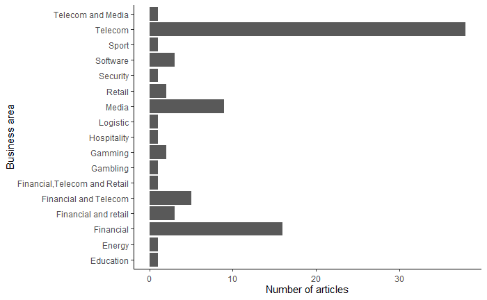

```r
g <- ggplot(data = data_asreview,aes(x = factor(businessArea)))+theme_minimal()+geom_bar(position = 'stack')
g +labs(x='Business area',y='Number of articles') + theme_classic()+theme(axis.text.x = element_text(angle = 0,vjust = 0.5))+coord_flip()
```

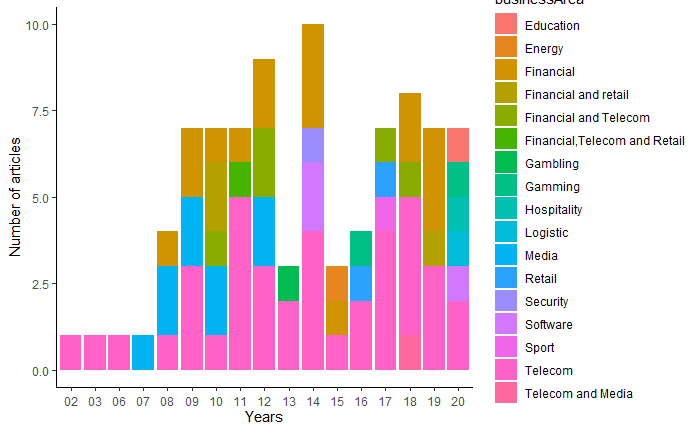

```r
library(RColorBrewer)
g<-ggplot(data = data_asreview) + aes(x = factor(substr(year,3,4)), fill = businessArea)+geom_bar()
g +labs(x='Years',y='Number of articles') + theme_classic()+theme(axis.text.x = element_text(angle = 0,vjust = 0.5)) + scale_colour_brewer(palette = "Greens")
```

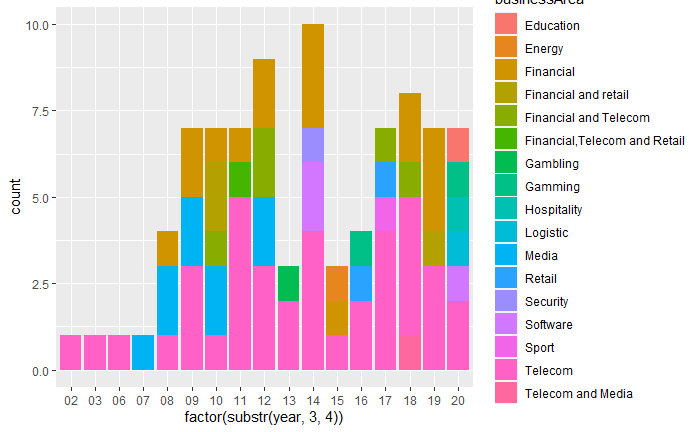

```r
g
```

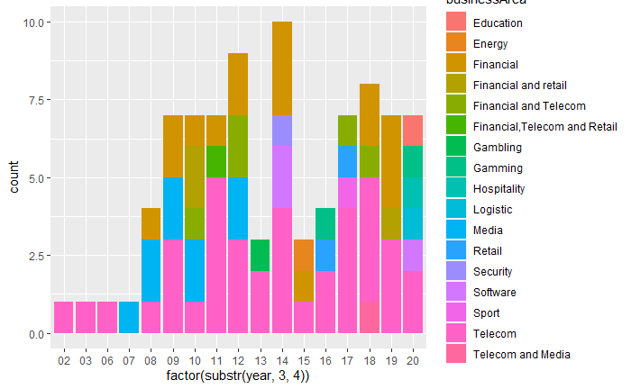

```r
g+scale_colour_brewer()
```

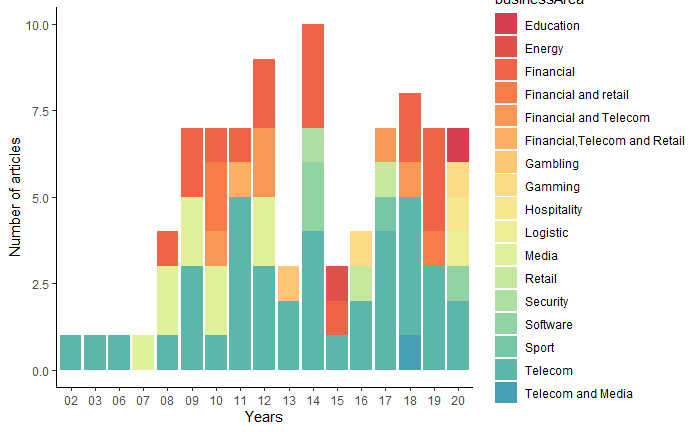

```r
colourCount = length(unique(data_asreview$year))
# Provide more one color to avoid
# Error: Insufficient values in manual scale
myColors <- colorRampPalette(brewer.pal(8, "Spectral"))(colourCount+1)
g+scale_fill_manual(values = myColors) +labs(x='Years',y='Number of articles')+ theme_classic()
ggsave('C:/nuvem/Dropbox/doutoramento/tese/1.sistematicReview/5f7ef8936c611800011b7ceb/figures/figure_articlesByBusinessArea.png')
```

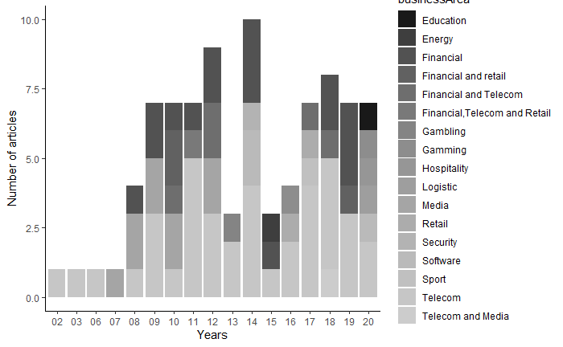

```r
g+scale_fill_grey(start=0.1,end=0.8) +labs(x='Years',y='Number of articles')+ theme_classic()
```

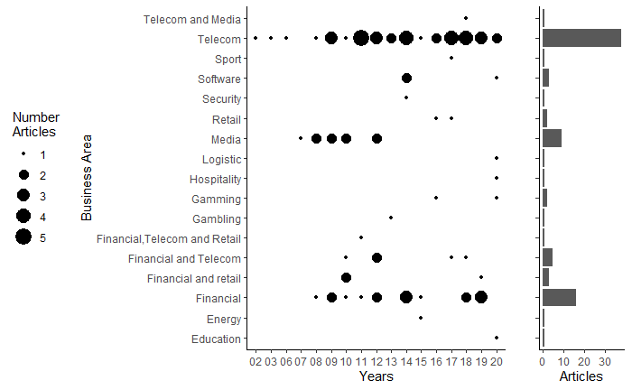

```r
library(gridExtra)
# total de artigos por ano e business area
by_business<- data_asreview %>%
                  group_by(year,businessArea)

resumo<-summarize(by_business,count = n())

g1<-ggplot() + geom_point(data = resumo, aes(x = substr(year,3,4), y = businessArea, size = count)) +
  theme_classic() +
  labs(x='Years',y='Business Area',size = 'Number\nArticles') +
  theme(legend.position="left")

# total de artigos por business area
g2 <- ggplot(data = data_asreview,aes(x = factor(businessArea)))+
  theme_classic()+
  geom_bar(position = 'stack') +
  labs(x='',y='Articles') +
  theme(axis.text.y=element_blank())+
  coord_flip()

# criar um boxplot com o número citações
#g3 <- ggplot(data_asreview, aes(x=, y=len, fill=dose)) +
#  geom_boxplot()


grid.arrange(g1,g2,widths = c(3,0.7))

g <- arrangeGrob(g1, g2, widths = c(3,0.7)) #generates g
ggsave(file="C:/nuvem/Dropbox/doutoramento/tese/1.sistematicReview/5f7ef8936c611800011b7ceb/figures/figure_articlesByBusinessArea.png", g) #saves g

ggsave('C:/nuvem/Dropbox/doutoramento/tese/1.sistematicReview/5f7ef8936c611800011b7ceb/figures/figure_articlesByBusinessArea_old.png')
```

## Publications in 2008 and 2014

```r
str(data_asreview)
```

```
tibble [87 x 14] (S3: tbl_df/tbl/data.frame)
 $ record_id       : num [1:87] 34 2 336 61 295 342 322 168 81 202 ...
 $ Unnamed: 0      : num [1:87] 36 3 355 63 313 361 340 177 83 214 ...
 $ category        : chr [1:87] "ARTICLE" "INPROCEEDINGS" "ARTICLE" "ARTICLE" ...
 $ year            : num [1:87] 2019 2015 2017 2017 2011 ...
 $ title           : chr [1:87] "A big data analytics model for customer churn prediction in the retiree segment" "A Case Study for the Churn Prediction in Turksat Internet Service Subscription" "A churn prediction model for prepaid customers in telecom using fuzzy classifiers" "A comparative analys…
 $ abstract        : chr [1:87] "Undoubtedly, the change in consumersâ\200\231 choices and expectations, stemming from the emerging technology a"| __truncated__ "Churn prediction is a customer relationship process that predicts for customers who are at the brink of transfe"| __truncated__ "The incre…
 $ doi             : chr [1:87] "https://doi.org/10.1016/j.ijinfomgt.2018.10.005" "10.1145/2808797.2808821" "10.1007/s11235-017-0310-7" "https://doi.org/10.1016/j.dss.2016.11.007" ...
 $ journal         : chr [1:87] "International Journal of Information Management" NA "Telecommunication Systems" "Decision Support Systems" ...
 $ bibtexkey       : chr [1:87] "SHIRAZI2019238" "10.1145/2808797.2808821" "azeem_churn_2017" "COUSSEMENT201727" ...
 $ author          : chr [1:87] "Farid Shirazi, Mahbobeh Mohammadi" "G\\\"ok, Mehmet, \\\"Ozyer, Tansel, Jida, Jamal" "Azeem, Muhammad, Usman, Muhammad, Fong, A. C. M." "Kristof Coussement, Stefan Lessmann, Geert Verstraeten" ...
 $ source          : chr [1:87] "SCIENCE" "ACM" "SPRINGER" "SCIENCE" ...
 $ final_included  : num [1:87] 1 1 1 1 1 1 1 1 1 1 ...
 $ asreview_ranking: num [1:87] 4 1 80 8 59 82 72 21 9 25 ...
 $ businessArea    : chr [1:87] "Financial" "Financial" "Telecom" "Telecom" ...
```

```r
print(data_asreview[data_asreview$year<'2008',c("year","title","author","journal","businessArea")])
```

| year | title | author | journal | businessArea |
| --- | --- | --- | --- | --- |
| 2003 | A novel evolutionary data mining algorithm with applications to churn prediction | Au, W.-H., Chan, C.C., Yao, X. | IEEE Transactions on Evolutionary Computation | Telecom |
| 2006 | Applying data mining to telecom churn management | Shin-Yuan Hung, David C. Yen, Hsiu-Yu Wang | Expert Systems with Applications | Telecom |
| 2007 | CRM at a pay-TV company: Using analytical models to reduce customer attrition by targeted marketing for subscription services | Burez, J., Van den Poel, D. | Expert Systems with Applications | Media |
| 2002 | Turning telecommunications call details to churn prediction: A data mining approach | Wei, C.-P., Chiu, I.-T. | Expert Systems with Applications | Telecom |

```r
print(data_asreview[data_asreview$year=='2008',c("year","title","author","journal","businessArea")])
```

| year | title | author | journal | businessArea |
| --- | --- | --- | --- | --- |
| 2008 | Churn prediction in subscription services: An application of support vector machines while comparing two parameter-selection techniques | Coussement, K., Van den Poel, D. | Expert Systems with Applications | Media |
| 2008 | Construction of Bayesian classifiers with GA for predicting customer retention | Hongmei, S., Gaofeng, Z., Fengxian, A. | NA | Financial |
| 2008 | Model of Customer Churn Prediction on Support Vector Machine | Guo-en XIA, Wei-dong JIN | Systems Engineering - Theory & Practice | Telecom |
| 2008 | Separating financial from commercial customer churn: A modeling step towards resolving the conflict between the sales and credit department | Burez, J., Van den Poel, D. | Expert Systems with Applications | Media |

```r
print(data_asreview[data_asreview$year=='2014',c("year","title","author","journal","businessArea")])
```

| year | title | author | journal | businessArea |
| --- | --- | --- | --- | --- |
| 2014 | Applicability of machine-learning techniques in predicting customer defection | Prasasti, N., Ohwada, H. | NA | Software |
| 2014 | Churn prediction using comprehensible support vector machine: An analytical CRM application | M.A.H. Farquad, Vadlamani Ravi, S. Bapi Raju | Applied Soft Computing | Financial |
| 2014 | Dynamic churn prediction framework with more effective use of rare event data: The case of private banking | Gür Ali, Ö., Aritürk, U. | Expert Systems with Applications | Financial |
| 2014 | Improved churn prediction in telecommunication industry using data mining techniques | A. Keramati, R. Jafari-Marandi, M. Aliannejadi, I. Ahmadian, M. Mozaffari, U. Abbasi | Applied Soft Computing | Telecom |
| 2014 | Prediction of customer attrition of commercial banks based on SVM model | He, B., Shi, Y., Wan, Q., Zhao, X. | NA | Financial |
| 2014 | Profit optimizing customer churn prediction with Bayesian network classifiers | Verbraken, T., Verbeke, W., Baesens, B. | Intelligent Data Analysis | Telecom |
| 2014 | Research on customers churn prediction model based on logistic | Jiang, M., Chu, N., Bi, X.M. | NA | Security |
| 2014 | Social network analysis for customer churn prediction | Verbeke, W., Martens, D., Baesens, B. | Applied Soft Computing Journal | Telecom |
| 2014 | The importance of social embeddedness: Churn models at mobile providers | Benedek, G., Lublóy, A., Vastag, G. | Decision Sciences | Telecom |
| 2014 | Utilizing Customersâ\200\231 Purchase and Contract Renewal Details to Predict Defection in the Cloud Software Industry | Martono, Niken Prasasti, Kanamori, Katsutoshi, Ohwada, Hayato | NA | Software |

## Publications addressing telecomunications, financial and media

```r
print(data_asreview[data_asreview$businessArea=='Telecom',c("year","title","author","journal","businessArea","bibtexkey")])
```

| year | title | author | journal | businessArea | bibtexkey |
| --- | --- | --- | --- | --- | --- |
| 2017 | A churn prediction model for prepaid customers in telecom using fuzzy classifiers | Azeem, Muhammad, Usman, Muhammad, Fong, A. C. M. | Telecommunication Systems | Telecom | azeem_churn_2017 |
| 2017 | A comparative analysis of data preparation algorithms for customer churn prediction: A case study in the telecommunication industry | Kristof Coussement, Stefan Lessmann, Geert Verstraeten | Decision Support Systems | Telecom | COUSSEMENT201727 |
| 2011 | A fuzzy prediction model for calling communities | Kianmehr, K., Alhajj, R. | International Journal of Networking and Virtual Organisations | Telecom | Kianmehr201175 |
| 2012 | A Graph-Based Churn Prediction Model for Mobile Telecom Networks | Saravanan, M., Vijay Raajaa, G. S. | NA | Telecom | hutchison_graph-based_2012 |
| 2003 | A novel evolutionary data mining algorithm with applications to churn prediction | Au, W.-H., Chan, C.C., Yao, X. | IEEE Transactions on Evolutionary Computation | Telecom | Au2003532 |
| 2019 | An efficient system for customer churn prediction through particle swarm optimization based feature selection model with simulated annealing | Vijaya, J., Sivasankar, E. | Cluster Computing | Telecom | Vijaya201910757 |
| 2018 | An innovative optimized model to anticipate clients about immigration in telecom industry | Naik, M.V., Reddy, S.S. | NA | Telecom | Naik2018232 |
| 2016 | Application of Computational Intelligence to Predict Churn and Non-Churn of Customers in Indian Telecommunication | Mohanty, R., Rani, K.J. | NA | Telecom | Mohanty2016598 |
| 2006 | Applying data mining to telecom churn management | Shin-Yuan Hung, David C. Yen, Hsiu-Yu Wang | Expert Systems with Applications | Telecom | HUNG2006515 |
| 2011 | Applying Fuzzy Data Mining to Telecom Churn Management | Liao, Kuo-Hsiung, Chueh, Hao-En | NA | Telecom | chen_applying_2011 |

[output cut: 28 more lines]

```r
print(data_asreview[data_asreview$businessArea=='Financial',c("year","title","author","journal","businessArea","bibtexkey")])
```

| year | title | author | journal | businessArea | bibtexkey |
| --- | --- | --- | --- | --- | --- |
| 2019 | A big data analytics model for customer churn prediction in the retiree segment | Farid Shirazi, Mahbobeh Mohammadi | International Journal of Information Management | Financial | SHIRAZI2019238 |
| 2015 | A Case Study for the Churn Prediction in Turksat Internet Service Subscription | G\\"ok, Mehmet, \\"Ozyer, Tansel, Jida, Jamal | NA | Financial | 10.1145/2808797.2808821 |
| 2012 | Analytical CRM in banking and finance using SVM: A modified active learning-based rule extraction approach | Farquad, M.A.H., Ravi, V., Raju, S.B. | International Journal of Electronic Customer Relationship Management | Financial | Farquad201248 |
| 2018 | Behavioral attributes and financial churn prediction | Kaya, E., Dong, X., Suhara, Y., Balcisoy, S., Bozkaya, B., Pentland, A.S. | EPJ Data Science | Financial | Kaya2018 |
| 2018 | Churn and non-churn of customers in banking sector using extreme learning machine | Mohanty, R., Naga Ratna Sree, C. | NA | Financial | Mohanty201851 |
| 2019 | Churn Prediction in Banking System using K-Means, LOF, and CBLOF | Ullah, I., Hussain, H., Ali, I., Liaquat, A. | NA | Financial | Ullah2019 |
| 2014 | Churn prediction using comprehensible support vector machine: An analytical CRM application | M.A.H. Farquad, Vadlamani Ravi, S. Bapi Raju | Applied Soft Computing | Financial | FARQUAD201431 |
| 2008 | Construction of Bayesian classifiers with GA for predicting customer retention | Hongmei, S., Gaofeng, Z., Fengxian, A. | NA | Financial | Hongmei2008181 |
| 2011 | Credit card churn forecasting by logistic regression and decision tree | Nie, G., Rowe, W., Zhang, L., Tian, Y., Shi, Y. | Expert Systems with Applications | Financial | Nie201115273 |
| 2009 | Customer churn prediction using improved balanced random forests | Xie, Y., Li, X., Ngai, E.W.T., Ying, W. | Expert Systems with Applications | Financial | Xie20095445 |

[output cut: 6 more lines]

```r
print(data_asreview[data_asreview$businessArea=='Media',c("year","title","author","journal","businessArea","bibtexkey")])
```

| year | title | author | journal | businessArea | bibtexkey |
| --- | --- | --- | --- | --- | --- |
| 2008 | Churn prediction in subscription services: An application of support vector machines while comparing two parameter-selection techniques | Coussement, K., Van den Poel, D. | Expert Systems with Applications | Media | Coussement2008313 |
| 2007 | CRM at a pay-TV company: Using analytical models to reduce customer attrition by targeted marketing for subscription services | Burez, J., Van den Poel, D. | Expert Systems with Applications | Media | Burez2007277 |
| 2012 | Customer event history for churn prediction: How long is long enough? | Ballings, M., Van Den Poel, D. | Expert Systems with Applications | Media | Ballings201213517 |
| 2009 | Handling class imbalance in customer churn prediction | Burez, J., Van den Poel, D. | NA | Media | Burez20094626 |
| 2010 | Improved marketing decision making in a customer churn prediction context using generalized additive models | Coussement, K., Benoit, D.F., Van den Poel, D. | Expert Systems with Applications | Media | Coussement20102132 |
| 2009 | Improving customer attrition prediction by integrating emotions from client/company interaction emails and evaluating multiple classifiers | Coussement, K., Poel, D.V.d. | Expert Systems with Applications | Media | Coussement20096127 |
| 2012 | Improving Customer Churn Prediction by Data Augmentation Using Pictorial Stimulus-Choice Data | Ballings, Michel, Van den Poel, Dirk, Verhagen, Emmanuel | NA | Media | casillas_improving_2012 |
| 2008 | Separating financial from commercial customer churn: A modeling step towards resolving the conflict between the sales and credit department | Burez, J., Van den Poel, D. | Expert Systems with Applications | Media | Burez2008497 |
| 2010 | Variable selection by association rules for customer churn prediction of multimedia on demand | Tsai, C.-F., Chen, M.-Y. | Expert Systems with Applications | Media | Tsai20102006 |

## Publications totals by business area

```r
table(data_asreview$businessArea)
```

```
                   Education                       Energy                    Financial         Financial and retail        Financial and Telecom Financial,Telecom and Retail
                           1                            1                           16                            3                            5                            1
                    Gambling                      Gamming                  Hospitality                     Logistic                        Media                       Retail
                           1                            2                            1                            1                            9                            2
                    Security                     Software                        Sport                      Telecom            Telecom and Media
                           1                            3                            1                           38                            1
```

```r
articles_by_businessArea<-summarize(group_by(data_asreview,businessArea),n = n(),.groups = 'keep')
articles_by_businessArea$freq = articles_by_businessArea$n/sum(articles_by_businessArea$n)*100

articles_by_businessArea
```

| businessArea | n | freq |
| --- | --- | --- |
| Education | 1 | 1.149425 |
| Energy | 1 | 1.149425 |
| Financial | 16 | 18.390805 |
| Financial and retail | 3 | 3.448276 |
| Financial and Telecom | 5 | 5.747126 |
| Financial,Telecom and Retail | 1 | 1.149425 |
| Gambling | 1 | 1.149425 |
| Gamming | 2 | 2.298851 |
| Hospitality | 1 | 1.149425 |
| Logistic | 1 | 1.149425 |

[output cut: 7 more lines]

```r
NA
```

```r
# Easy with the janitor package
library("janitor")

tabyl(data_asreview$businessArea)
```

```
   data_asreview$businessArea  n    percent
                    Education  1 0.01149425
                       Energy  1 0.01149425
                    Financial 16 0.18390805
         Financial and retail  3 0.03448276
        Financial and Telecom  5 0.05747126
 Financial,Telecom and Retail  1 0.01149425
                     Gambling  1 0.01149425
                      Gamming  2 0.02298851
                  Hospitality  1 0.01149425
                     Logistic  1 0.01149425
                        Media  9 0.10344828
                       Retail  2 0.02298851
                     Security  1 0.01149425
                     Software  3 0.03448276
                        Sport  1 0.01149425
                      Telecom 38 0.43678161
            Telecom and Media  1 0.01149425
```

```r
print(data_asreview[data_asreview$businessArea=='Financial and retail',c("year","title","author","journal","businessArea","bibtexkey")])
```

| year | title | author | journal | businessArea | bibtexkey |
| --- | --- | --- | --- | --- | --- |
| 2010 | Applying CHAID for logistic regression diagnostics and classification accuracy improvement | Antipov, Evgeny, Pokryshevskaya, Elena | Journal of Targeting, Measurement and Analysis for Marketing | Financial and retail | antipov_applying_2010 |
| 2010 | Ensembles of Probability Estimation Trees for Customer Churn Prediction | De Bock, Koen W., Van den Poel, Dirk | NA | Financial and retail | garcia-pedrajas_ensembles_2010 |
| 2019 | Social network analysis in Telecom data | Al-Molhem, Nour Raeef, Rahal, Yasser, Dakkak, Mustapha | Journal of Big Data | Financial and retail | al-molhem_social_2019 |

```r
print(data_asreview[data_asreview$businessArea=='Financial,Telecom and Retail',c("year","title","author","journal","businessArea","bibtexkey")])
```

| year | title | author | journal | businessArea | bibtexkey |
| --- | --- | --- | --- | --- | --- |
| 2011 | An empirical evaluation of rotation-based ensemble classifiers for customer churn prediction | Koen W. De Bock, Dirk Van den Poel | Expert Systems with Applications | Financial,Telecom and Retail | DEBOCK201112293 |

```r
print(data_asreview[data_asreview$businessArea=='Telecom and Media',c("year","title","author","journal","businessArea","bibtexkey")])
```

| year | title | author | journal | businessArea | bibtexkey |
| --- | --- | --- | --- | --- | --- |
| 2018 | Retention futility: Targeting high-risk customers might be ineffective | Ascarza, E. | Journal of Marketing Research | Telecom and Media | Ascarza201880 |

```r
print(data_asreview[data_asreview$businessArea=='Financial and Telecom',c("year","title","author","journal","businessArea","bibtexkey")])
```

| year | title | author | journal | businessArea | bibtexkey |
| --- | --- | --- | --- | --- | --- |
| 2012 | Dynamic classifier ensemble model for customer classification with imbalanced class distribution | Xiao, J., Xie, L., He, C., Jiang, X. | Expert Systems with Applications | Financial and Telecom | Xiao20123668 |
| 2017 | Intelligent data analysis approaches to churn as a business problem: a survey | García, D.L., Nebot, Ã\200., Vellido, A. | Knowledge and Information Systems | Financial and Telecom | García2017719 |
| 2018 | Profit-Based Model Selection for Customer Retention Using Individual Customer Lifetime Values | Óskarsdóttir, M., Baesens, B., Vanthienen, J. | Big Data | Financial and Telecom | Óskarsdóttir201853 |
| 2012 | Reconciling performance and interpretability in customer churn prediction using ensemble learning based on generalized additive models | De Bock, K.W., Van Den Poel, D. | Expert Systems with Applications | Financial and Telecom | DeBock20126816 |
| 2010 | Staying Power of Churn Prediction Models | Hans Risselada, Peter C. Verhoef, Tammo H.A. Bijmolt | Journal of Interactive Marketing | Financial and Telecom | RISSELADA2010198 |

## Logistic, Hospitality, Education

```r
print(data_asreview[data_asreview$businessArea=='Logistic',c("year","title","author","journal","businessArea","bibtexkey")])
```

| year | title | author | journal | businessArea | bibtexkey |
| --- | --- | --- | --- | --- | --- |
| 2020 | Forecasting client retention â\200” A machine-learning approach | Satu Elisa Schaeffer, Sara Veronica Rodriguez Sanchez | Journal of Retailing and Consumer Services | Logistic | SCHAEFFER2020101918 |

```r
print(data_asreview[data_asreview$businessArea=='Hospitality',c("year","title","author","journal","businessArea","bibtexkey")])
```

| year | title | author | journal | businessArea | bibtexkey |
| --- | --- | --- | --- | --- | --- |
| 2020 | Estimating customer churn under competing risks | Routh, P., Roy, A., Meyer, J. | Journal of the Operational Research Society | Hospitality | Routh2020 |

```r
print(data_asreview[data_asreview$businessArea=='Education',c("year","title","author","journal","businessArea","bibtexkey")])
```

| year | title | author | journal | businessArea | bibtexkey |
| --- | --- | --- | --- | --- | --- |
| 2020 | Development of a Bayesian Belief Network-based DSS for predicting and understanding freshmen student attrition | Dursun Delen, Kazim Topuz, Enes Eryarsoy | European Journal of Operational Research | Education | DELEN2020575 |

## Common words in the title and abstract

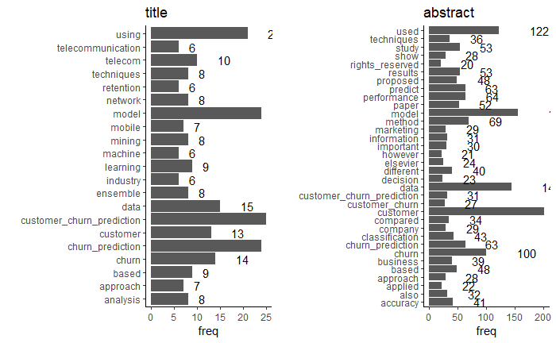

```r
library(revtools)
library(gridExtra)

# Title frequencies
x_dtm<-make_dtm(data_asreview$title,min_freq = 0.06)

#create a matrix of the document term-matrix
x_dtm_matrix <- as.matrix(x_dtm)
#apply function to calculate columns totals
totals<-apply(x_dtm_matrix,MARGIN = 2,sum)

#create dataframe
df_dtm<-data.frame(totals)
df_dtm$words<-row.names(df_dtm)

g1<-ggplot(data = df_dtm,aes(x=words,y=totals)) +
  labs(title = "title",x='',y = "freq")+ #modify legend and plot labels
  geom_bar(stat = "identity") + coord_flip()+
  geom_text(aes(label=totals),hjust=-1.6) + theme_classic()

# frequencia no abstract
x_dtm<-make_dtm(data_asreview$abstract,min_freq = 0.20)

#create a matrix of the document term-matrix
x_dtm_matrix <- as.matrix(x_dtm)
#apply function to calculate columns totals
totals<-apply(x_dtm_matrix,MARGIN = 2,sum)

#create dataframe
df_dtm<-data.frame(totals)
df_dtm$words<-row.names(df_dtm)

g2<-ggplot(data = df_dtm,aes(x=words,y=totals)) +
  labs(title = "abstract",x='',y = "freq")+ #modify legend and plot labels
  geom_bar(stat = "identity") + coord_flip()+
  geom_text(aes(label=totals),hjust=-1.6) + theme_classic()


library(cowplot)
plot_grid(g1, g2, align = "h", ncol = 2, rel_heights = c(1/2, 1/2))

ggsave("../../1.sistematicReview/5f7ef8936c611800011b7ceb/figures/commonWords.png")
```

# Export

```r
library(writexl)
```